# Part II - Loan Prosper Exploration

## Visualization 2: Net Loss on Prosper Loan distribution.

Question: Could the loss on Prosper Loan distribution be offsetted by the recoveries?

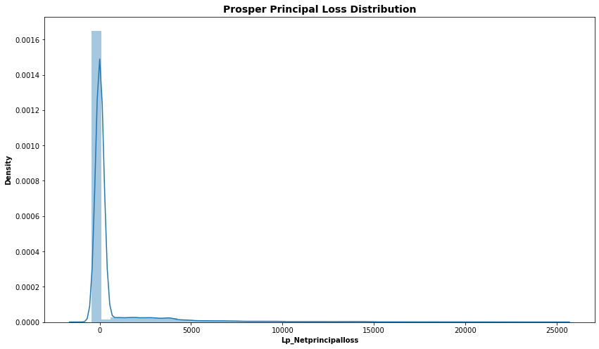

## Visualization 3: listing category = 20 (20 - Wedding Loans) observes the largest loan prosper amount

Question:

- Out of the listing, which category observes the largest Prosper Principal Outstanding?

Out of the listing category, the listing category = 20 (1 - Wedding ) is the category that observes the most loan amount in the range 0-10000.

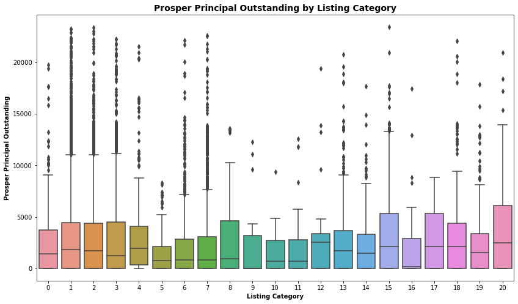